# Import Dữ Liệu

```python
import pandas as pd
import matplotlib.pyplot as plt
import numpy as np
from scipy import stats
from scipy.stats import norm
import seaborn as sns
```

```python
btc=pd.read_excel('BTC-USD.xlsx')
btc['Date']=pd.to_datetime(btc['Date'])
btc.sort_values(by=['Date'],inplace=True,ascending=True)
btc.set_index('Date', inplace=True)
print(btc.head(5))
print(btc.columns)
print(btc.head)
```

```
                    Open          High           Low         Close  \
Date
2018-01-01  14112.200195  14112.200195  13154.700195  13657.200195
2018-01-02  13625.000000  15444.599609  13163.599609  14982.099609
2018-01-03  14978.200195  15572.799805  14844.500000  15201.000000
2018-01-04  15270.700195  15739.700195  14522.200195  15599.200195
2018-01-05  15477.200195  17705.199219  15202.799805  17429.500000

               Adj Close       Volume
Date
2018-01-01  13657.200195  10291200000
2018-01-02  14982.099609  16846600192
2018-01-03  15201.000000  16871900160
2018-01-04  15599.200195  21783199744
2018-01-05  17429.500000  23840899072
Index(['Open', 'High', 'Low', 'Close', 'Adj Close', 'Volume'], dtype='object')
<bound method NDFrame.head of                     Open          High           Low         Close  \
Date
2018-01-01  14112.200195  14112.200195  13154.700195  13657.200195
2018-01-02  13625.000000  15444.599609  13163.599609  14982.099609
2018-01-03  14978.200195  15572.799805  14844.500000  15201.000000
2018-01-04  15270.700195  15739.700195  14522.200195  15599.200195
2018-01-05  15477.200195  17705.199219  15202.799805  17429.500000
...                  ...           ...           ...           ...
2020-11-27  17153.914062  17445.023438  16526.423828  17108.402344
2020-11-28  17112.933594  17853.939453  16910.652344  17717.414062
2020-11-29  17719.634766  18283.628906  17559.117188  18177.484375
2020-11-30  18178.322266  19749.263672  18178.322266  19625.835938
2020-12-01  19633.769531  19845.974609  18321.921875  18802.998047

               Adj Close       Volume
Date
2018-01-01  13657.200195  10291200000
2018-01-02  14982.099609  16846600192
2018-01-03  15201.000000  16871900160
2018-01-04  15599.200195  21783199744
2018-01-05  17429.500000  23840899072
...                  ...          ...
2020-11-27  17108.402344  38886494645
2020-11-28  17717.414062  32601040734
2020-11-29  18177.484375  31133957704
2020-11-30  19625.835938  47728480399
2020-12-01  18802.998047  49633658712

[1066 rows x 6 columns]>
```

```python
Price = btc.drop(['Open', 'High', 'Low', 'Adj Close', 'Volume'], axis=1)
```

# Tiền xử lí dữ liệu

```python
Price.isnull()
Price.duplicated()
```

```
Date
2018-01-01    False
2018-01-02    False
2018-01-03    False
2018-01-04    False
2018-01-05    False
              ...
2020-11-27    False
2020-11-28    False
2020-11-29    False
2020-11-30    False
2020-12-01    False
Length: 1066, dtype: bool
```

```python
Price.describe()
```

|  | Close |
| --- | --- |
| count | 1066.000000 |
| mean | 8319.956978 |
| std | 2880.927791 |
| min | 3236.761719 |
| 25% | 6500.099976 |
| 50% | 8244.671875 |
| 75% | 9921.347168 |
| max | 19625.835938 |

```python
display(Price.info())
```

```
<class 'pandas.core.frame.DataFrame'>
DatetimeIndex: 1066 entries, 2018-01-01 to 2020-12-01
Data columns (total 1 columns):
 #   Column  Non-Null Count  Dtype
---  ------  --------------  -----
 0   Close   1066 non-null   float64
dtypes: float64(1)
memory usage: 16.7 KB
```

```
None
```

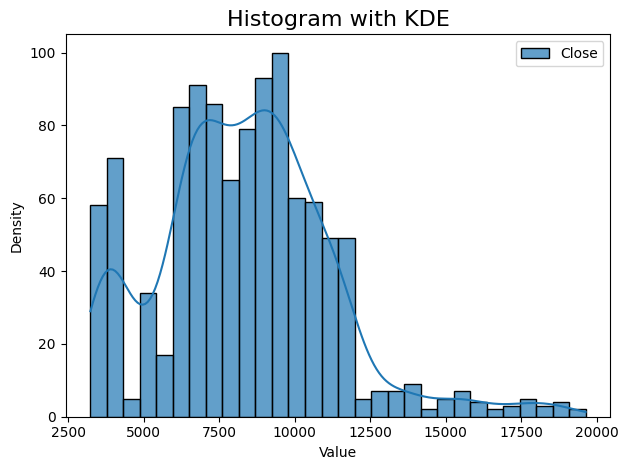

```python
import matplotlib.pyplot as plt
import warnings
warnings.filterwarnings("ignore")
sns.histplot(Price, kde=True, bins=30, color='blue', alpha=0.7)
plt.title('Histogram with KDE', size=16)
plt.xlabel('Value')
plt.ylabel('Density')
plt.tight_layout()
plt.show()
```

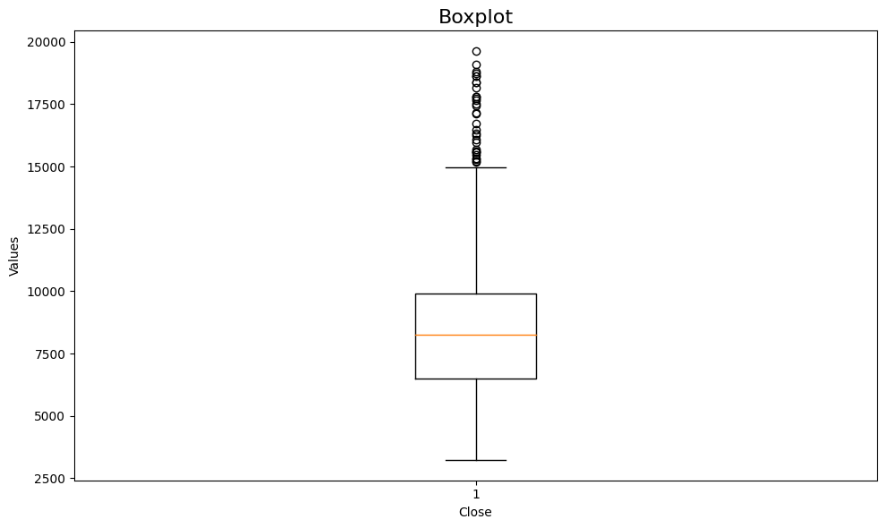

```python
import matplotlib.pyplot as plt
import warnings
warnings.filterwarnings("ignore")
plt.figure(figsize=(10, 6))
plt.boxplot(Price)
plt.title('Boxplot', size=16)
plt.xlabel('Close')
plt.ylabel('Values')
plt.tight_layout()
plt.show()
```

Trong quá trình làm sách ta thấy biến dự đoán của chúng ta có nhiều outlier nên ta sẽ tiến hành loại bỏ outlier bằng phương pháp IQR

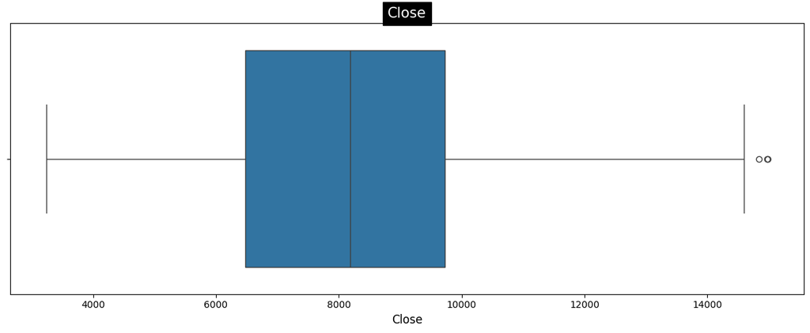

```
(1034, 1)
```

```python
plt.figure(figsize=(12,5))
drop_outlier_col = Price
for idx, i in enumerate(drop_outlier_col):
    Q1 = Price[i].quantile(0.25)
    Q3 = Price[i].quantile(0.75)
    IQR = Q3 - Q1
    lower_bound = Q1 - 1.5 * IQR
    upper_bound = Q3 + 1.5 * IQR
    Price = Price[(Price[i] >= lower_bound) & (Price[i] <= upper_bound)]
    sns.boxplot(x=i, data=Price)
    plt.title(i, backgroundcolor='black', color='white', fontsize=15)
    plt.xlabel(i, size=12)

plt.tight_layout()
plt.show()
Price.shape
```

Sau khi loại bỏ outlier cho biến dự đoán của chúng ta thì ta thấy mặc dù vẫn còn số ít outlier còn sót nhưng nhìn chung biến của chúng ta đã được làm sạch đáng kể

# Arima Model

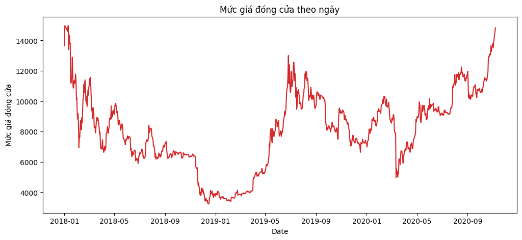

```
                   Close
Date
2018-01-01  13657.200195
2018-01-02  14982.099609
2018-01-09  14595.400391
2018-01-10  14973.299805
2018-01-11  13405.799805
...                  ...
2020-11-01  13737.109375
2020-11-02  13550.489258
2020-11-03  13950.300781
2020-11-04  14133.707031
2020-11-07  14833.753906

[1034 rows x 1 columns]
```

```python
def plot_df(Price, y, title="", xlabel='Date', ylabel='Mức giá đóng cửa', dpi=100):
    plt.figure(figsize=(12,5), dpi=dpi)
    plt.plot(y, color='tab:red')
    plt.gca().set(title=title, xlabel=xlabel, ylabel=ylabel)
    plt.show()


plot_df(Price, y=Price, title='Mức giá đóng cửa theo ngày')
print(Price)
```

## Decomposition of a Time Series

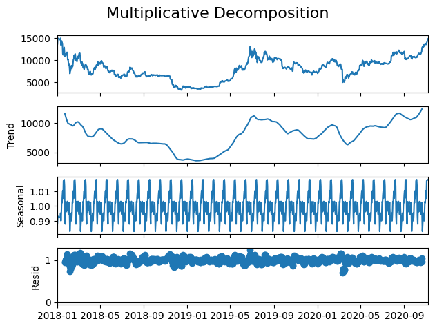

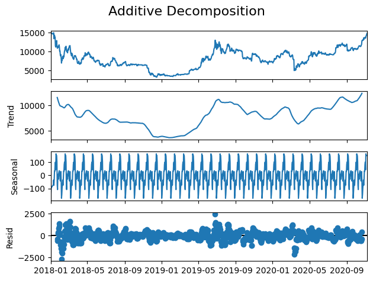

```python
from statsmodels.tsa.seasonal import seasonal_decompose
from dateutil.parser import parse
Phantachnhan = seasonal_decompose(Price, model='multiplicative', period=30)
Phantachcong = seasonal_decompose(Price, model='additive', period=30)
plt.figure(figsize=(12,5))
Phantachnhan.plot().suptitle('Multiplicative Decomposition', fontsize=16)
plt.tight_layout()
Phantachcong.plot().suptitle('Additive Decomposition', fontsize=16)
plt.tight_layout()
plt.show()
```

Đâu tiên thì chúng ta sẽ phân rã dãy số thời gian để xem xu hướng, mùa vụ cũng như là nhiễu

## Stationary and Non-Stationary Time Series

```python
from statsmodels.tsa.arima_model import ARIMA
import statsmodels.api as sm
from statsmodels.tsa.stattools import adfuller
from statsmodels.graphics.tsaplots import plot_acf, plot_pacf
from sklearn.metrics import mean_squared_error
```

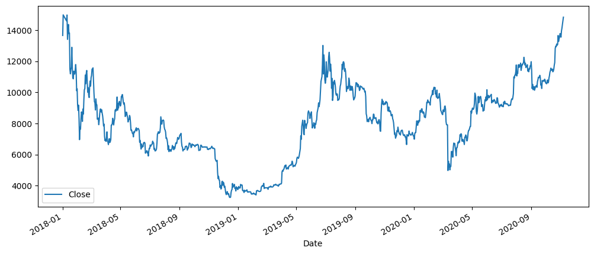

```python
plt.tight_layout()
Price.plot(figsize=(12,5))
```

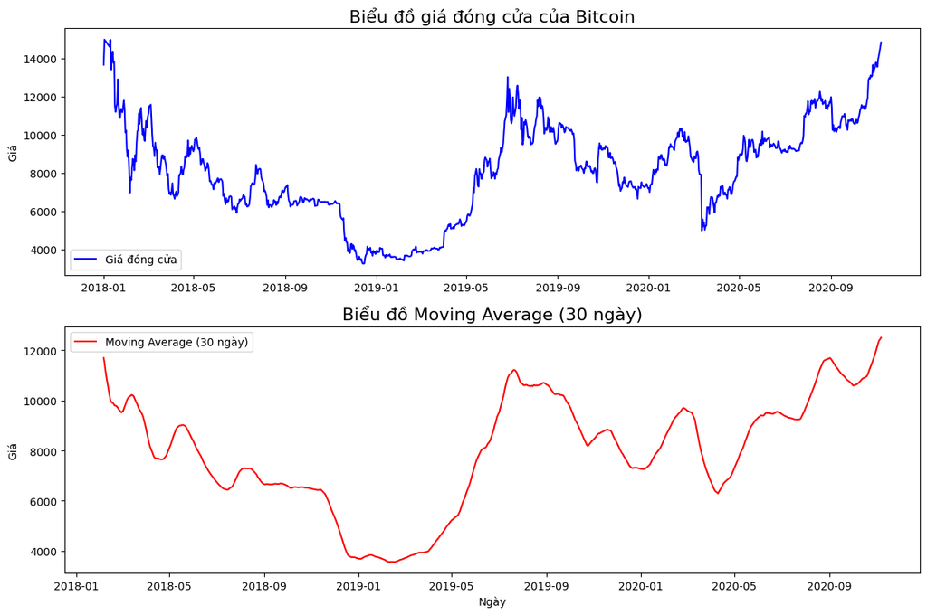

```python
moving_avg = Price.rolling(window=30).mean()
fig, (ax1, ax2) = plt.subplots(2, 1, figsize=(12, 8))
ax1.plot(Price, label='Giá đóng cửa', color='blue')
ax1.set_title('Biểu đồ giá đóng cửa của Bitcoin', fontsize=16)
ax1.set_ylabel('Giá')
ax1.legend()
ax2.plot(moving_avg, color='red', label='Moving Average (30 ngày)')
ax2.set_title('Biểu đồ Moving Average (30 ngày)', fontsize=16)
ax2.set_xlabel('Ngày')
ax2.set_ylabel('Giá')
ax2.legend()
plt.tight_layout()
plt.show()
```

```python
def adf_test(Price):
  result=adfuller(Price)
  labels=['adf_test','p_values','Độ trễ','Độ quan sát']
  for value,label in zip(result,labels):
    print(label + ' : ' +str(value))
  if result[1]<=0.05:
    print('Đủ điều kiện bác bỏ H0 dữ liệu có tính dừng (Chấp nhận H0)')
  else:
    print('Chưa đủ điều kiện bác bỏ H0 dữ liệu không có tính dừng (Chấp nhận H1)')
adf_test(Price)
```

```
adf_test : -2.087730145865558
p_values : 0.2494769077873089
Độ trễ : 2
Độ quan sát : 1031
Chưa đủ điều kiện bác bỏ H0 dữ liệu không có tính dừng (Chấp nhận H1)
```

Để xây dựng được ARIMA model thì chuỗi thời gian của chúng ta phải là chuỗi dừng vì mô hình ARIMA sẽ giả định chuỗi thời gian của ta đã dừng nên ta sẽ dùng phương pháp kiểm ra là ADF

ADF là một phương pháp kiểm tra xem ở trong chuỗi thời gian của chúng ta có nút gốc hay không. Chúng ta sẽ có cập giả thuyết bao gồm:

- H0: có 1 nút gốc, chuỗi chưa dừng
- H1: không có nút gốc, chuỗi đã dừng

Trong trường hợp này:

## Make a time series stationary by Differencing the Series

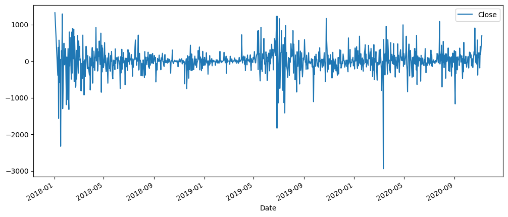

```python
dt=Price.diff().dropna()
dt.plot(figsize=(12,5))
```

Tiếp theo ta sẽ tiến hành sai phân bậc 1 thường được sử dụng để loại bỏ xu hướng tuyến tính từ dữ liệu và biến đổi dữ liệu thành dạng có tính dừng, làm cho nó phù hợp hơn cho việc xây dựng các mô hình dự báo chuỗi thời gian như mô hình ARIMA.

```python
adf_test(dt)
```

```
adf_test : -22.43629689926186
p_values : 0.0
Độ trễ : 1
Độ quan sát : 1031
Đủ điều kiện bác bỏ H0 dữ liệu có tính dừng (Chấp nhận H0)
```

## Autocorrelation and Partial Autocorrelation Functions

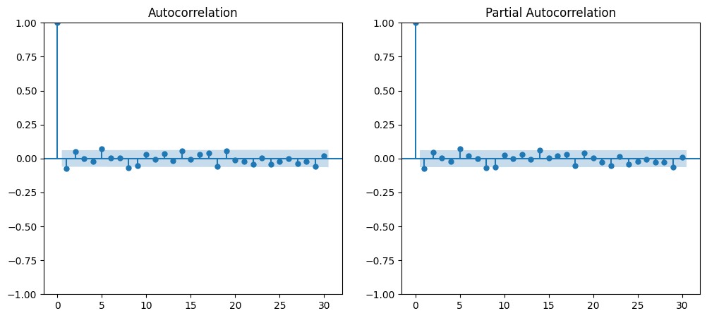

```python
from statsmodels.tsa.stattools import acf, pacf
from statsmodels.graphics.tsaplots import plot_acf, plot_pacf
fig, axes = plt.subplots(1, 2, figsize=(12, 5), dpi=100)
plot_acf(dt, lags=30, ax=axes[0])
plot_pacf(dt, lags=30, ax=axes[1])
plt.show()
```

Tiếp đến ta sẽ vẽ biểu đồ ACF và biểu đồ PACF để tiến hành xác định chỉ số p và q.

Trong trường hợp này ta sẽ vẽ ra để xác định chỉ số qmin, qmax cũng như là pmin, pmax để sử dụng pmdarima xác định kịch bản tốt nhất cho mô hình

## Arima Model

```python
!pip install pmdarima
```

```
     ━━━━━━━━━━━━━━━━━━━━━━━━━━━━━━━━━━━━━━━━ 2.1/2.1 MB 8.0 MB/s eta 0:00:00
```

```python
from sklearn.model_selection import train_test_split
train_data, test_data = train_test_split(Price, test_size=0.3, shuffle=False)
```

```python
import pmdarima as pm
def arima(timeseries):
  automodel=pm.auto_arima(timeseries,
                          start_p=0,
                          start_q=0,
                          d=1,
                          max_p=8,
                          max_q=8,
                          test='adf',
                          seasonal=False,
                          trace=True)
  return automodel
arima(dt)
```

```
Performing stepwise search to minimize aic
 ARIMA(0,1,0)(0,0,0)[0] intercept   : AIC=15711.416, Time=0.08 sec
 ARIMA(1,1,0)(0,0,0)[0] intercept   : AIC=15329.910, Time=0.07 sec
 ARIMA(0,1,1)(0,0,0)[0] intercept   : AIC=inf, Time=0.50 sec
 ARIMA(0,1,0)(0,0,0)[0]             : AIC=15709.418, Time=0.05 sec
 ARIMA(2,1,0)(0,0,0)[0] intercept   : AIC=15211.974, Time=0.34 sec
 ARIMA(3,1,0)(0,0,0)[0] intercept   : AIC=15159.546, Time=0.38 sec
 ARIMA(4,1,0)(0,0,0)[0] intercept   : AIC=15088.916, Time=1.02 sec
 ARIMA(5,1,0)(0,0,0)[0] intercept   : AIC=15063.367, Time=0.68 sec
 ARIMA(6,1,0)(0,0,0)[0] intercept   : AIC=15048.402, Time=3.23 sec
 ARIMA(7,1,0)(0,0,0)[0] intercept   : AIC=15048.195, Time=3.79 sec
 ARIMA(8,1,0)(0,0,0)[0] intercept   : AIC=15046.446, Time=5.80 sec
 ARIMA(8,1,1)(0,0,0)[0] intercept   : AIC=inf, Time=13.49 sec
 ARIMA(7,1,1)(0,0,0)[0] intercept   : AIC=inf, Time=11.56 sec
 ARIMA(8,1,0)(0,0,0)[0]             : AIC=15044.430, Time=2.44 sec
 ARIMA(7,1,0)(0,0,0)[0]             : AIC=15046.194, Time=1.68 sec
 ARIMA(8,1,1)(0,0,0)[0]             : AIC=inf, Time=8.16 sec
 ARIMA(7,1,1)(0,0,0)[0]             : AIC=inf, Time=4.08 sec

Best model:  ARIMA(8,1,0)(0,0,0)[0]
Total fit time: 57.411 seconds
```

```
 ARIMA(8,1,0)(0,0,0)[0]
```

Tiến dành chọn ra kịch bản tốt nhất bằng pmdarima trong với chỉ số AIC thấp nhất

Giá trị AIC càng nhỏ thì mô hình được coi là càng tốt. Điều này đồng nghĩa với việc mô hình có hiệu suất dự đoán tốt và độ phức tạp thấp. Khi so sánh các mô hình, mô hình có giá trị AIC nhỏ nhất được ưu tiên lựa chọn.

```python
from statsmodels.tsa.arima.model import ARIMA
model= ARIMA(Price,order=(8,1,0))
model_fit=model.fit()
print(model_fit.summary())
```

```
                               SARIMAX Results
==============================================================================
Dep. Variable:                  Close   No. Observations:                 1034
Model:                 ARIMA(8, 1, 0)   Log Likelihood               -7459.912
Date:                Tue, 04 Jun 2024   AIC                          14937.823
Time:                        04:53:26   BIC                          14982.285
Sample:                             0   HQIC                         14954.695
                               - 1034
Covariance Type:                  opg
==============================================================================
                 coef    std err          z      P>|z|      [0.025      0.975]
------------------------------------------------------------------------------
ar.L1         -0.0562      0.019     -2.960      0.003      -0.093      -0.019
ar.L2          0.0444      0.024      1.854      0.064      -0.003       0.091
ar.L3          0.0058      0.022      0.258      0.797      -0.038       0.050
ar.L4         -0.0375      0.018     -2.070      0.038      -0.073      -0.002
ar.L5          0.0809      0.021      3.814      0.000       0.039       0.122
ar.L6          0.0256      0.022      1.147      0.251      -0.018       0.069
ar.L7         -0.0118      0.022     -0.541      0.589      -0.055       0.031
ar.L8         -0.0744      0.022     -3.355      0.001      -0.118      -0.031
sigma2      1.097e+05   2071.985     52.933      0.000    1.06e+05    1.14e+05
===================================================================================
Ljung-Box (L1) (Q):                   0.54   Jarque-Bera (JB):              5128.74
Prob(Q):                              0.46   Prob(JB):                         0.00
Heteroskedasticity (H):               0.72   Skew:                            -1.13
Prob(H) (two-sided):                  0.00   Kurtosis:                        13.68
===================================================================================

Warnings:
[1] Covariance matrix calculated using the outer product of gradients (complex-step).
```

Model: Mô hình được sử dụng, trong trường hợp này là ARIMA.

Log Likelihood: Giá trị Log-Likelihood của mô hình, được sử dụng để so sánh với các mô hình khác.

AIC (Akaike Information Criterion): Một tiêu chí đánh giá chất lượng của mô hình, càng thấp càng tốt.

BIC (Bayesian Information Criterion): Một tiêu chí đánh giá chất lượng của mô hình, tương tự như AIC.

sigma2: Độ biến động của phần dư, được tính bằng cách chia tổng bình phương phần dư cho số lượng quan sát.

Ljung-Box (L1): Kiểm định Ljung-Box cho phần dư của mô hình, được sử dụng để kiểm tra tính tự tương quan trong phần dư. Trong trường hợp này, giá trị kiểm định Ljung-Box là 0.54 với P values là 0.46

Jarque-Bera (JB): Kiểm định Jarque-Bera cho phần dư của mô hình, được sử dụng để kiểm tra phân phối chuẩn của phần dư. Trong trường hợp này, giá trị kiểm định Jarque-Bera là 5128.74 với p-value là 0.00.

Heteroskedasticity (H): Kiểm tra heteroskedasticity trong phần dư của mô hình. Trong trường hợp này, giá trị p-value của kiểm tra heteroskedasticity là 0.00.

Skew: Độ méo của phần dư. Trong trường hợp này, giá trị độ méo là -1.13. Cho thấy biểu đồ phân phối chuẩn đang lệch trái. Phân phối lệch trái (tức là có nhiều giá trị nhỏ hơn trung tâm hơn so với phân phối chuẩn).

Kurtosis: Độ nhọn của phần dư. Trong trường hợp này, giá trị độ nhọn là 13.68.

## Make Time Series Prediction

```python
#Dự đoán giá đóng cửa
close_filtered=model_fit.fittedvalues.loc[model_fit.fittedvalues !=0]
close_filtered
```

```
Date
2018-01-02    13575.605632
2018-01-09    14958.100057
2018-01-10    14677.700997
2018-01-11    14890.487278
2018-01-12    13567.246872
                  ...
2020-11-01    13823.690413
2020-11-02    13733.403854
2020-11-03    13549.870949
2020-11-04    13884.958638
2020-11-07    14190.009564
Length: 1033, dtype: float64
```

```python
Price
```

| Date | Close |
| --- | --- |
| 2018-01-01 | 13657.200195 |
| 2018-01-02 | 14982.099609 |
| 2018-01-09 | 14595.400391 |
| 2018-01-10 | 14973.299805 |
| 2018-01-11 | 13405.799805 |
| ... | ... |
| 2020-11-01 | 13737.109375 |
| 2020-11-02 | 13550.489258 |
| 2020-11-03 | 13950.300781 |
| 2020-11-04 | 14133.707031 |
| 2020-11-07 | 14833.753906 |

1034 rows × 1 columns

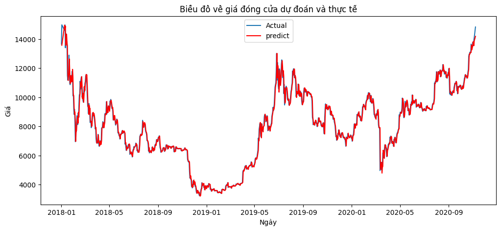

```python
plt.figure(figsize=(12,5))
plt.plot(Price,label='Actual')
plt.plot(close_filtered,label='predict',color='red')
plt.title('Biểu đồ về giá đóng cửa dự đoán và thực tế')
plt.xlabel('Ngày')
plt.ylabel('Giá')
plt.legend(loc='upper center')
plt.show()
```

```python
#Dự báo cho 10 ngày tiếp theo
price_future=model_fit.forecast(10)
price_future
```

```
1034    14800.611591
1035    14792.542170
1036    14799.301321
1037    14802.644045
1038    14874.448158
1039    14854.204380
1040    14834.881854
1041    14783.974638
1042    14786.173908
1043    14790.852906
Name: predicted_mean, dtype: float64
```

## Tách dữ liệu Train và dữ liệu Test

```python
from statsmodels.tsa.arima.model import ARIMA
model1= ARIMA(train_data,order=(8,1,0))
model_fit1=model1.fit()
print(model_fit1.summary())
```

```
                               SARIMAX Results
==============================================================================
Dep. Variable:                  Close   No. Observations:                  723
Model:                 ARIMA(8, 1, 0)   Log Likelihood               -5223.689
Date:                Tue, 04 Jun 2024   AIC                          10465.377
Time:                        04:53:42   BIC                          10506.615
Sample:                             0   HQIC                         10481.295
                                - 723
Covariance Type:                  opg
==============================================================================
                 coef    std err          z      P>|z|      [0.025      0.975]
------------------------------------------------------------------------------
ar.L1         -0.0308      0.021     -1.484      0.138      -0.072       0.010
ar.L2          0.0204      0.026      0.783      0.434      -0.031       0.072
ar.L3          0.0356      0.025      1.434      0.152      -0.013       0.084
ar.L4         -0.0932      0.022     -4.214      0.000      -0.137      -0.050
ar.L5          0.0939      0.023      4.011      0.000       0.048       0.140
ar.L6          0.0300      0.024      1.227      0.220      -0.018       0.078
ar.L7          0.0209      0.028      0.742      0.458      -0.034       0.076
ar.L8         -0.0970      0.024     -4.006      0.000      -0.145      -0.050
sigma2      1.131e+05   3373.406     33.513      0.000    1.06e+05     1.2e+05
===================================================================================
Ljung-Box (L1) (Q):                   1.07   Jarque-Bera (JB):               989.89
Prob(Q):                              0.30   Prob(JB):                         0.00
Heteroskedasticity (H):               0.84   Skew:                            -0.58
Prob(H) (two-sided):                  0.18   Kurtosis:                         8.62
===================================================================================

Warnings:
[1] Covariance matrix calculated using the outer product of gradients (complex-step).
```

```python
start=len(train_data)
end=len(train_data)+len(test_data)-1
prediction=model_fit1.predict(start=start,end=end,typ='levels')
prediction
```

```
723     7304.983445
724     7309.026844
725     7302.761503
726     7330.799050
727     7315.422346
           ...
1029    7311.857822
1030    7311.857822
1031    7311.857822
1032    7311.857822
1033    7311.857822
Name: predicted_mean, Length: 311, dtype: float64
```

```python
prediction_series = pd.Series(prediction.values, index=test_data.index)
prediction_series
```

```
Date
2019-12-31    7304.983445
2020-01-01    7309.026844
2020-01-02    7302.761503
2020-01-03    7330.799050
2020-01-04    7315.422346
                 ...
2020-11-01    7311.857822
2020-11-02    7311.857822
2020-11-03    7311.857822
2020-11-04    7311.857822
2020-11-07    7311.857822
Length: 311, dtype: float64
```

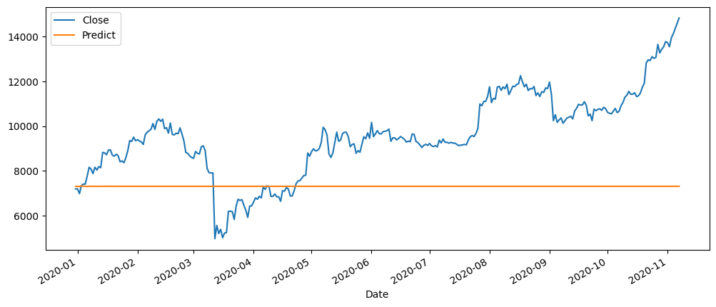

```python
test_data['Close'].plot(legend=True,figsize=(12,5))
prediction_series.plot(legend=True,label='Predict')
```

```
Mean Absolute Error (MAE): 2448.449703743092
Mean Squared Error (MSE): 8241643.981191215
Root Mean Squared Error (RMSE): 2870.8263585928034
Mean Absolute Percentage Error (MAPE): nan
```

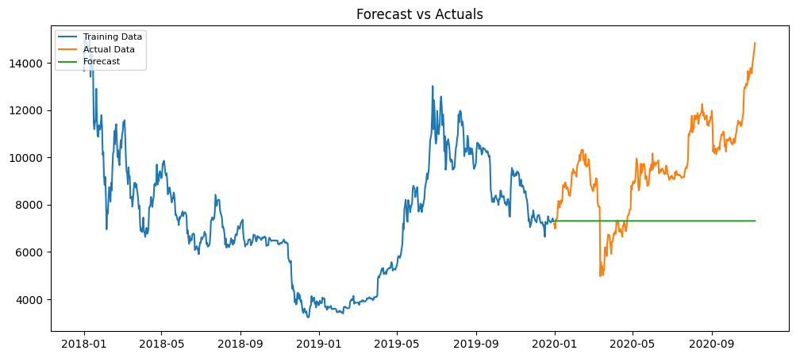

```python
from sklearn.metrics import mean_absolute_error, mean_squared_error
mae = mean_absolute_error(test_data, prediction_series)
mse = mean_squared_error(test_data, prediction_series)
rmse = np.sqrt(mse)
mape = np.mean(np.abs((test_data - prediction_series) / test_data)) * 100
print('Mean Absolute Error (MAE):', mae)
print('Mean Squared Error (MSE):', mse)
print('Root Mean Squared Error (RMSE):', rmse)
print('Mean Absolute Percentage Error (MAPE):', mape)
plt.figure(figsize=(12, 5), dpi=100)
plt.plot(train_data, label='Training Data')
plt.plot(test_data, label='Actual Data')
plt.plot(prediction_series, label='Forecast')
plt.title('Forecast vs Actuals')
plt.legend(loc='upper left', fontsize=8)
plt.show()
```

```python
ARIMA_Forecast=model_fit1.forecast(10)
ARIMA_Forecast
```

```
723    7304.983445
724    7309.026844
725    7302.761503
726    7330.799050
727    7315.422346
728    7312.584305
729    7301.813497
730    7311.290986
731    7313.476805
732    7312.358220
Name: predicted_mean, dtype: float64
```

## Sarima Model

```python
from statsmodels.tsa.statespace.sarimax import SARIMAX
model_sarima=sm.tsa.statespace.SARIMAX(Price['Close'], order=(8,1,0),seasonal_order=(8,1,0,12),enforce_stationarity=False,enforce_invertibility=False)
Results=model_sarima.fit()
Sarimax_Predict=Results.predict()
Sarimax_Pre=pd.DataFrame(list(zip(list(Sarimax_Predict.index),list(Sarimax_Predict))),columns=['Date','Sarimax_predict']).set_index('Date')
Sarimax_Predict_df=pd.merge(Price[1:],Sarimax_Pre,left_index=True,right_index=True)
Sarimax_Predict_df.tail(10)
print(Results.summary())
```

```
                                     SARIMAX Results
==========================================================================================
Dep. Variable:                              Close   No. Observations:                 1034
Model:             SARIMAX(8, 1, 0)x(8, 1, 0, 12)   Log Likelihood               -6544.674
Date:                            Tue, 04 Jun 2024   AIC                          13123.348
Time:                                    04:56:01   BIC                          13205.307
Sample:                                         0   HQIC                         13154.629
                                           - 1034
Covariance Type:                              opg
==============================================================================
                 coef    std err          z      P>|z|      [0.025      0.975]
------------------------------------------------------------------------------
ar.L1         -0.0821      0.023     -3.548      0.000      -0.127      -0.037
ar.L2          0.0164      0.028      0.583      0.560      -0.039       0.071
ar.L3          0.0036      0.026      0.140      0.889      -0.047       0.055
ar.L4          0.0353      0.026      1.356      0.175      -0.016       0.086
ar.L5          0.0373      0.029      1.283      0.199      -0.020       0.094
ar.L6         -0.0038      0.028     -0.136      0.892      -0.058       0.051
ar.L7         -0.0079      0.023     -0.344      0.731      -0.053       0.037
ar.L8         -0.0500      0.030     -1.691      0.091      -0.108       0.008
ar.S.L12      -0.8553      0.027    -31.352      0.000      -0.909      -0.802
ar.S.L24      -0.7634      0.041    -18.466      0.000      -0.844      -0.682
ar.S.L36      -0.6694      0.046    -14.653      0.000      -0.759      -0.580
ar.S.L48      -0.5743      0.046    -12.362      0.000      -0.665      -0.483
ar.S.L60      -0.4566      0.050     -9.196      0.000      -0.554      -0.359
ar.S.L72      -0.3328      0.050     -6.678      0.000      -0.430      -0.235
ar.S.L84      -0.1985      0.045     -4.395      0.000      -0.287      -0.110
ar.S.L96      -0.0915      0.035     -2.626      0.009      -0.160      -0.023
sigma2      9.262e+04   2023.843     45.763      0.000    8.87e+04    9.66e+04
===================================================================================
Ljung-Box (L1) (Q):                   0.01   Jarque-Bera (JB):              6293.52
Prob(Q):                              0.91   Prob(JB):                         0.00
Heteroskedasticity (H):               2.85   Skew:                            -1.06
Prob(H) (two-sided):                  0.00   Kurtosis:                        15.66
===================================================================================

Warnings:
[1] Covariance matrix calculated using the outer product of gradients (complex-step).
```

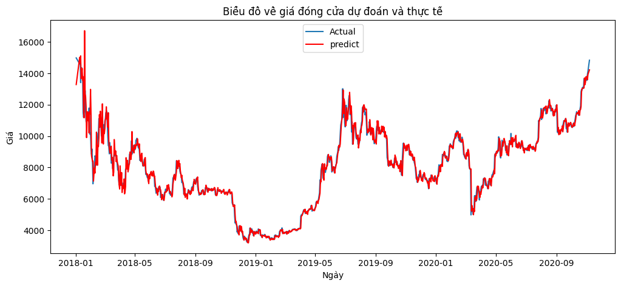

```python
plt.figure(figsize=(12,5))
plt.plot(Sarimax_Predict_df['Close'],label='Actual')
plt.plot(Sarimax_Predict_df['Sarimax_predict'],label='predict',color='red')
plt.title('Biểu đồ về giá đóng cửa dự đoán và thực tế')
plt.xlabel('Ngày')
plt.ylabel('Giá')
plt.legend(loc='upper center')
plt.show()
```

```python
Sarimax_Forecast=Results.forecast(10)
Sarimax_Forecast
```

```
1034    14710.040053
1035    14711.955197
1036    14817.611868
1037    14904.257321
1038    14955.428491
1039    14959.018688
1040    15162.002953
1041    15090.550546
1042    15090.421096
1043    15177.560281
Name: predicted_mean, dtype: float64
```

## Tách dữ liệu train và test

```python
from statsmodels.tsa.statespace.sarimax import SARIMAX
model_sarima1=sm.tsa.statespace.SARIMAX(train_data, order=(8,1,0),seasonal_order=(8,1,0,12),enforce_stationarity=False,enforce_invertibility=False)
Results1=model_sarima.fit()
print(Results1.summary())
```

```
                                     SARIMAX Results
==========================================================================================
Dep. Variable:                              Close   No. Observations:                 1034
Model:             SARIMAX(8, 1, 0)x(8, 1, 0, 12)   Log Likelihood               -6544.674
Date:                            Tue, 04 Jun 2024   AIC                          13123.348
Time:                                    04:58:28   BIC                          13205.307
Sample:                                         0   HQIC                         13154.629
                                           - 1034
Covariance Type:                              opg
==============================================================================
                 coef    std err          z      P>|z|      [0.025      0.975]
------------------------------------------------------------------------------
ar.L1         -0.0821      0.023     -3.548      0.000      -0.127      -0.037
ar.L2          0.0164      0.028      0.583      0.560      -0.039       0.071
ar.L3          0.0036      0.026      0.140      0.889      -0.047       0.055
ar.L4          0.0353      0.026      1.356      0.175      -0.016       0.086
ar.L5          0.0373      0.029      1.283      0.199      -0.020       0.094
ar.L6         -0.0038      0.028     -0.136      0.892      -0.058       0.051
ar.L7         -0.0079      0.023     -0.344      0.731      -0.053       0.037
ar.L8         -0.0500      0.030     -1.691      0.091      -0.108       0.008
ar.S.L12      -0.8553      0.027    -31.352      0.000      -0.909      -0.802
ar.S.L24      -0.7634      0.041    -18.466      0.000      -0.844      -0.682
ar.S.L36      -0.6694      0.046    -14.653      0.000      -0.759      -0.580
ar.S.L48      -0.5743      0.046    -12.362      0.000      -0.665      -0.483
ar.S.L60      -0.4566      0.050     -9.196      0.000      -0.554      -0.359
ar.S.L72      -0.3328      0.050     -6.678      0.000      -0.430      -0.235
ar.S.L84      -0.1985      0.045     -4.395      0.000      -0.287      -0.110
ar.S.L96      -0.0915      0.035     -2.626      0.009      -0.160      -0.023
sigma2      9.262e+04   2023.843     45.763      0.000    8.87e+04    9.66e+04
===================================================================================
Ljung-Box (L1) (Q):                   0.01   Jarque-Bera (JB):              6293.52
Prob(Q):                              0.91   Prob(JB):                         0.00
Heteroskedasticity (H):               2.85   Skew:                            -1.06
Prob(H) (two-sided):                  0.00   Kurtosis:                        15.66
===================================================================================

Warnings:
[1] Covariance matrix calculated using the outer product of gradients (complex-step).
```

```python
start=len(train_data)
end=len(train_data)+len(test_data)-1
prediction1=Results1.predict(start=start,end=end,typ='levels')
prediction1
```

```
Date
2019-12-31     7328.306856
2020-01-01     7289.069238
2020-01-02     7170.941749
2020-01-03     6926.898255
2020-01-04     7295.437476
                  ...
2020-11-01    13741.606727
2020-11-02    13803.417696
2020-11-03    13597.535867
2020-11-04    13928.578358
2020-11-07    14220.018292
Name: predicted_mean, Length: 311, dtype: float64
```

```python
prediction_series_sarima = pd.Series(prediction1.values, index=test_data.index)
prediction_series_sarima
```

```
Date
2019-12-31     7328.306856
2020-01-01     7289.069238
2020-01-02     7170.941749
2020-01-03     6926.898255
2020-01-04     7295.437476
                  ...
2020-11-01    13741.606727
2020-11-02    13803.417696
2020-11-03    13597.535867
2020-11-04    13928.578358
2020-11-07    14220.018292
Length: 311, dtype: float64
```

```python
test_data['Close']
```

```
Date
2019-12-31     7193.599121
2020-01-01     7200.174316
2020-01-02     6985.470215
2020-01-03     7344.884277
2020-01-04     7410.656738
                  ...
2020-11-01    13737.109375
2020-11-02    13550.489258
2020-11-03    13950.300781
2020-11-04    14133.707031
2020-11-07    14833.753906
Name: Close, Length: 311, dtype: float64
```

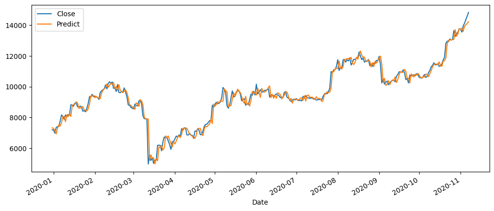

```python
test_data['Close'].plot(legend=True,figsize=(12,5))
prediction_series_sarima.plot(legend=True,label='Predict')
```

```
Mean Absolute Error (MAE): 211.7164631888409
Mean Squared Error (MSE): 109835.02738026244
Root Mean Squared Error (RMSE): 331.4136801344544
Mean Absolute Percentage Error (MAPE): nan
```

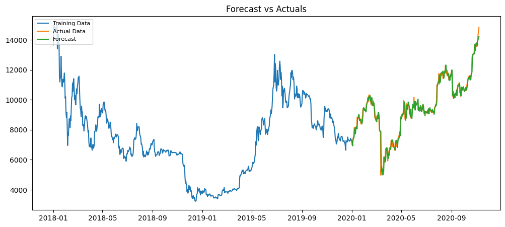

```python
from sklearn.metrics import mean_absolute_error, mean_squared_error
mae = mean_absolute_error(test_data, prediction_series_sarima)
mse = mean_squared_error(test_data, prediction_series_sarima)
rmse = np.sqrt(mse)
mape = np.mean(np.abs((test_data - prediction_series_sarima) / test_data)) * 100
print('Mean Absolute Error (MAE):', mae)
print('Mean Squared Error (MSE):', mse)
print('Root Mean Squared Error (RMSE):', rmse)
print('Mean Absolute Percentage Error (MAPE):', mape)
plt.figure(figsize=(12, 5), dpi=100)
plt.plot(train_data, label='Training Data')
plt.plot(test_data, label='Actual Data')
plt.plot(prediction_series_sarima, label='Forecast')
plt.title('Forecast vs Actuals')
plt.legend(loc='upper left', fontsize=8)
plt.show()
```

So sánh các chỉ số:

Mean Absolute Error (MAE):

MAE đo lường độ lớn trung bình của các sai số dự đoán. Mô hình 1 có MAE = 2448.45, trong khi Mô hình 2 có MAE = 211.72. MAE của Mô hình 2 thấp hơn rất nhiều so với Mô hình 1, cho thấy Mô hình 2 có các dự đoán gần với giá trị thực tế hơn.

Mean Squared Error (MSE):

MSE đo lường bình phương trung bình của các sai số dự đoán, làm nổi bật các sai số lớn hơn.

Mô hình 1 có MSE = 8241643.98, trong khi Mô hình 2 có MSE = 109835.03. MSE của Mô hình 2 thấp hơn rất nhiều so với Mô hình 1, cho thấy Mô hình 2 có hiệu suất tốt hơn, đặc biệt là trong việc giảm các sai số lớn.

Root Mean Squared Error (RMSE):

RMSE là căn bậc hai của MSE và cũng đo lường độ lớn trung bình của các sai số dự đoán. Mô hình 1 có RMSE = 2870.83, trong khi Mô hình 2 có RMSE = 331.41. RMSE của Mô hình 2 thấp hơn rất nhiều so với Mô hình 1, cho thấy Mô hình 2 có các dự đoán chính xác hơn.

```python
Sarimax_Forecast=Results1.forecast(10)
Sarimax_Forecast
```

```
1034    14710.040053
1035    14711.955197
1036    14817.611868
1037    14904.257321
1038    14955.428491
1039    14959.018688
1040    15162.002953
1041    15090.550546
1042    15090.421096
1043    15177.560281
Name: predicted_mean, dtype: float64
```

```python
!jupyter nbconvert --to html abc.ipynb
```

```
[NbConvertApp] Converting notebook abc.ipynb to html
[NbConvertApp] Writing 1863031 bytes to abc.html
```